# PIBI Notebook

Zachary M. Smith

2017-12-07

## Introduction

This R-script and documentation was created to calculate the Phytoplankton Index of Biotic Integrity (PIBI) for the Chesapeake Bay and its tidal tributaries developed by [Lacouture et al. (2006)](https://www.potomacriver.org/focus-areas/aquatic-life/phytoplankton-index-of-biotic-integrity-for-chesapeake-bay/). The following text documents the process used to prepare and calculate the PIBI. Data was acquired from the Chesapeake Bay Program’s (CBP) CEDR database.

### Getting Started

Load the necessary packages into the environment.

```r
library(tidyverse)
library(lubridate)
library(stringr)
library(readxl)
library(httr)
library(RCurl)
```

**mmir** is a costume package that I am developing to calculate taxonomic community metrics. The development version of **mmir** can be downloaded from [my GitHub account](https://github.com/zsmith27/mmir) using `devtools::install_github(repo = "zsmith27/mmir")`. After the installation **mmir** must be loaded into the environment using `library()`.

```r
library(mmir)
```

The `clean_string()` function modifies character objects by removing leading/trailing white space, converting all characters to lower case, and replacing all spaces (" “) with an underscore (”_“). These specifications eliminate common typos and standardize character objects.

```r
clean_string <- function(x) {
  x %>%
    stringr::str_trim() %>%
    tolower() %>%
    stringr::str_replace_all("\\s+", " ") %>%
    stringr::str_replace_all(" ", "_") %>%
    if_else(. == "", as.character(NA), .)
}
```

The `clean_up()` function is a wrapper for `clean_string()`. This function applies `clean_string()` to the column headers and character columns of data frames. Again, this process standardizes character values and makes it easier work with the data.

```r
clean_up <- function(x) {
  x %>%
    rename_all(clean_string) %>%
    mutate_if(is.character, funs(clean_string))%>%
    distinct()
}
```

Data for this document are located in various files. The object `project.dir` represents the phytoplankton project directory and will be used as the root of the file path throughout the document.

```r
project.dir <- "D:/ZSmith/Projects/PIBI/phyto"
```

## Prepare Taxonomic Hierarchy

### ITIS

The [Integrated Taxonomic Information System (ITIS) database](https://itis.gov/downloads/index.html) was downloaded in August of 2017 as a PostgreSQL database. The ITIS database is a useful resource for obtaining taxonomic hierarchy information. The majority of taxa observed in the Chesapeake Bay and its tributaries can be found in the database; however, there are a number of taxa that require edits or are missing entirely from the database. The following script documents the process used to import and modify tibbles from the ITIS database for PIBI purposes.

Establish the connection to the local ITIS PostgreSQL database.

```r
source(file.path(project.dir, "conn_postgres.R"))
#on.exit(dbDisconnect(conn), add = TRUE)
```

Import taxa hierarchy data from the ITIS database.

```r
hier.df <- tbl(conn, "hierarchy") %>%
  data.frame() %>%
  clean_up()
```

Import synonym data from the ITIS database. This information is used to identify and convert invalid tsn’s to accepted tsn’s.

```r
syn.df <- tbl(conn, "synonym_links") %>%
  select(1:2) %>%
  data.frame() %>%
  clean_up()
```

Import NODC data from the ITIS database. Several taxa in the CEDR database were assigned a NODC code but not a tsn. Many of the NODC codes can be correctly linked to an accepted tsn using this table. If a leading zero is present in the `nodc_id` column, then it is removed to be consistent with the NODC code format found in the CBP data.

```r
nodc.df <- tbl(conn, "nodc_ids") %>%
  select(nodc_id, tsn) %>%
  data.frame() %>%
  clean_up() %>%
  mutate(nodc_id = gsub("^[0]", "", nodc_id)) %>%
  rename(nodccode = nodc_id,
         nodc_tsn = tsn)
```

The “kingdom” data is imported from the ITIS database and joined to the “taxon_unit_types” data below.

```r
kingdoms <- tbl(conn, "kingdoms") %>%
  select(1:2) %>%
  data.frame() %>%
  clean_up()
```

*Section* and *Subsection* represent different taxonomic ranks for the Animailia and Plantae kingdoms. Therefore, the appropriate kingdom suffix was added to the end of each of the ranks to keep these ranks separate and allow them to be sorted in the correct order.

```r
taxa.types <- tbl(conn, "taxon_unit_types") %>%
  select(kingdom_id, rank_id, rank_name) %>%
  distinct() %>%
  arrange(rank_id) %>%
  data.frame() %>%
  clean_up() %>%
  left_join(kingdoms, by = "kingdom_id") %>%
  mutate(rank_name = case_when(
    rank_id == 124 ~ "section_animalia",
    rank_id == 126 ~ "subsection_animalia",
    rank_id == 200 ~ "section_plantae",
    rank_id == 210 ~ "subsection_plantae",
    TRUE ~ rank_name
  ))
```

The “taxonomic_units” ITIS table provides all of the TSNs and there associated Kingdom, rank IDs, and Latin names.

```r
taxa.units <- tbl(conn, "taxonomic_units") %>%
  select(tsn, name_usage, kingdom_id, rank_id, complete_name) %>%
  distinct() %>%
  data.frame() %>%
  clean_up()

#DBI::dbDisconnect(conn$con) %>% invisible()
#closeAllConnections()
```

The `taxa.units` and `taxa.types` data frames are joined together by the `kingdom_id` and `rank_id` columns to replace the `rank_id` in `taxa.units` with the associated `rank_name` from `taxa.types.

```r
taxa.df <- left_join(taxa.units, taxa.types, by = c("kingdom_id", "rank_id")) %>%
  select(-kingdom_id, -rank_id, -kingdom_name)
```

Clean up the global environment by removing all unnecessary objects.

```r
rm(conn, kingdoms, taxa.types, taxa.units)
```

### Taxonomic Data

CBP taxonomic count data is imported and `Methods` other than “PH”, **PH**-ytoplankton methods, are excluded from the data frame. Additionally, taxa identified as “Micro-phytoflagellates”, “Green cells”, or “Blue green sphere” were excluded from this analysis because these taxa could not be identified to a discernible taxon, and therefore are not useful.

Several of the NODC codes contain character values that are not present in the ITIS NODC codes. These character values were appended on to valid NODC codes to identify taxa (e.g., species or subspecies) that are not in the NODC database. To obtain as much taxonomic hierarchy data as possible for these taxa, the character values are removed and, when applicable, the numeric values are matched to valid NODC codes and subsequently ITIS `tsn` values. The numeric values are extracted from the `nodccode` column and any leading zeros are removed.

```r
col.class.vec <- c("SampleNumber" = "character",
                   "TSN" = "character",
                   "SPECCode" = "character",
                   "ReportingValue" = "integer")

lrr.df <- data.table::fread(file.path(project.dir, "data/taxa/LivingResourcesReportedHUC8.csv"),
                            data.table = FALSE,
                            colClasses = col.class.vec) %>%
  clean_up()

odu.phyto <- data.table::fread(file.path(project.dir, "data/taxa/ODU_2013_2016_Phytoplankton_Data_07jul17_mod2.csv"),
                               data.table = FALSE,
                               colClasses = col.class.vec) %>%
  clean_up()

odu.pico <- data.table::fread(file.path(project.dir, "data/taxa/ODU_2013_2016_Picoplankton_Data_07jul17.csv"),
                              data.table = FALSE,
                              colClasses = col.class.vec) %>%
  clean_up()
```

The three CSVs imported above are appended together. The PIBI was developed for the taxa found above the pycnocline. Therefore, rows where the layer column does not specifies above the pycnocline (“ap”) or water column (“wc”) are removed. Furthermore, [Lacouture et al. (2006 pg. 599)](https://www.potomacriver.org/focus-areas/aquatic-life/phytoplankton-index-of-biotic-integrity-for-chesapeake-bay/) developed indices for data collected in the spring (March-May) and summer (July-September).

```r
bay.df <- bind_rows(lrr.df, odu.phyto, odu.pico) %>%
  filter(layer %in% c("ap", "wc")) %>%
  distinct() %>%
  mutate(sampledate = as.Date(sampledate, "%m/%d/%Y"),
         month = month(sampledate),
         season = case_when(
           month %in% c(3, 4, 5) ~ "spring",
           month %in% c(7, 8, 9) ~ "summer",
           TRUE ~ "remove"
         )) %>%
  filter(season %in% c("spring", "summer"))
```

If there are multiple taxa with the same taxonomic name, then the reporting values should be summed. Each row should represent a unique taxon.

```r
bay.df <- bay.df %>%
  group_by_at(vars(-reportingvalue)) %>%
  summarize(reportingvalue = sum(reportingvalue)) %>%
  ungroup()
```

Clean up the global environment by removing all unnecessary objects.

```r
rm(lrr.df, odu.phyto, odu.pico)
```

Only phytoplankton data (“ph”) is retained for analysis. Additionally, some taxa were not identified to any useful taxonomic rank and were excluded from the analysis.

```r
bay.df <- bay.df %>%
  # Removes methods with prefix "BE" (Tidal Benthic Taxa Enumeration) or blanks.
  filter(grepl("ph", method),
         !latinname %in% c("micro-phytoflagellates", "microflagellates",
                           "green_cells",
                           "blue_green_sphere", "epiphytic_flagellates"))
```

Non-numeric values and leading zeros were removed from the `nodccode` to make it possible to use this field to merge with data from the ITIS database.

```r
bay.df <- bay.df %>%
  mutate(nodc_num = gsub("[^0-9]", "", nodccode),
         nodc_num = gsub("^[0]", "", nodc_num))
```

The `tsn_accepted` column from syn.df is used to identify all currently valid TSNs in the ITIS database. `nodc.df` is filtered to keep only nodc codes associated with valid TSN values.

```r
accepted.vec <- unique(syn.df$tsn_accepted)

nodc.df <- nodc.df %>%
         filter(nodc_tsn %in% accepted.vec)
```

The ITIS NODC data frame is joined with the taxonomic counts. If the reported TSN equals zero and the `nodc_tsn` is not `NA`, then the `nodc_tsn` is used to fill in the `final_tsn` column; otherwise, the reported `tsn` is used as the `final_tsn`. NODC codes “7030526” and “7403100180” were not found in the ITIS NODC codes. These NODC codes were specifically assigned the appropriate `final_tsn`.

```r
bay.df <- bay.df %>%
  left_join(nodc.df, by = c("nodc_num" = "nodccode")) %>%
  mutate(final_tsn = case_when(
    !is.na(nodc_tsn) & tsn == 0 ~ as.integer(nodc_tsn),
    stringr::str_detect(tsn, "bay") ~ as.integer(nodc_tsn),
    TRUE ~ suppressWarnings(as.integer(tsn))),
    final_tsn = case_when(
      nodc_num == "7030526" ~ as.integer(3649),
      nodc_num == "7403100180" ~ as.integer(5204),
      TRUE ~ as.integer(final_tsn)
    ))
```

The ninth taxon, Didymocystis, was assigned the wrong TSN. ITIS contains the genus Didymocystis under the phylum platyhelminthes. This Didymocystis should be classified under the division Chlorophyta; however, this genus does not exist in the ITIS database. The TSN for the family Didymocystis belongs to, Oocystaceae, was assigned and used to obtain most of the taxonomic information for this taxon. Similarly, the tenth taxon, Lauterborniella elegantissima, is the name for an insect of the family Chironomidae or algae of the family Scenedesmaceae. We assume that reported taxon was algae but, again, there is no ITIS TSN for this taxon. The TSN for the Scenedesmaceae was used to obtain the majority of the taxonomic information. The genus and species names are appended later in the script. The `final_tsn` is updated to link to the appropriate taxonomic name in ITIS.

```r
bay.df <- bay.df %>%
  mutate(
    final_tsn = case_when(
      latinname == "navicula_notablis" ~ as.integer(4327),
      latinname == "pleurosigma_macrum" ~ as.integer(4650),
      latinname == "pleurosigma_obscurum" ~ as.integer(591383),
      latinname == "polykrikos_hartmannii" ~ as.integer(331299),
      latinname == "protoperidinium_aciculiderum" ~ as.integer(10329),
      latinname == "protoperidinium_paulseni" ~ as.integer(3568),
      latinname == "scrippsiella_favionese" ~ as.integer(10537),
      latinname == "tetrastrum_caudatum" ~ as.integer(5691),
      latinname == "didymocystis" ~ as.integer(5810),
      latinname == "lauterborniella_elegantissima" ~ as.integer(6097),
      latinname == "characium_sp." ~ as.integer(5756),
      latinname == "cylindrospermopsis_sp." ~ as.integer(203689),
      TRUE ~ final_tsn
    )
  )
```

The ITIS synonym data is joined with the taxonomic counts to identify TSN’s that are no longer valid and to assign the valid TSN.

```r
bay.df <- bay.df %>%
  left_join(syn.df, by = c("final_tsn" = "tsn")) %>%
  mutate(
    final_tsn = if_else(
      is.na(tsn_accepted),
      final_tsn,
      tsn_accepted
    ),
    unique_id = paste(station, layer, samplenumber, sampledate, sep = "_")) %>%
  select(unique_id, everything())
```

#### Taxonomic Hierarchy

In the ITIS database the taxonomic hierarchy is listed as a single string of TSNs separated by hyphens (“-”). To utilize the taxonomic information the string needs to separated into individual TSNs. The number of TSNs in the strings is inconsistent, and therefore the string that contains the most hyphens is used to identify the number of columns necessary to split all of the strings. `stringer::str_count()` is used to count the number of hyphens in each string, which is identified in the column `hyphen_count`. The max `hyphen_count` plus one is used to specify the necessary number of columns. `tidyr::separate()` is used to split the string by the hyphen into multiple columns. Most strings will not fill all of the columns. The remaining columns are filled with `NA`. The split TSNs are then transformed to a long data format using `tidyr::gather()` and the `NAs` are removed.

```r
hier.long <- hier.df %>%
  filter(tsn %in% unique(bay.df$final_tsn)) %>%
  mutate(hyphen_count = stringr::str_count(hierarchy_string, '-')) %>%
  separate(hierarchy_string,
           into = paste("tsn", seq(1:(max(.$hyphen_count) + 1)), sep = "_"),
           extra = "drop",
           fill = "right") %>%
  select(-parent_tsn, -level, -childrencount, -hyphen_count) %>%
  rename(final_tsn = tsn) %>%
  gather(col_name, tsn, -final_tsn, na.rm = TRUE) %>%
  select(-col_name) %>%
  mutate(tsn = as.numeric(tsn))
```

`hier.vec` is a vector of all of the taxonomic ranks in ITIS sorted in the correct order. This vector will be used to sort the the succeeding data frame into the appropriate order.

```r
hier.vec <- c("kingdom", "subkingdom", "infrakingdom",
              "superdivision", "division", "subdivision", "infradivision",
              "superphylum", "phylum", "subphylum", "infraphylum",
              "superclass", "class", "subclass", "infraclass",
              "superorder", "order", "suborder", "infraorder",
              "section_animalia", "subsection_animalia",
              "superfamily", "family", "subfamily",
              "tribe", "subtribe",
              "genus", "subgenus",
              "section_botany", "subsection_botany",
              "species", "subspecies",
              "variety", "form", "race", "stirp", "morph", "aberration", "unspecified")
```

`hier.long` only contains a list of TSNs, which are not informative. The data is joined with the `taxa.df` data frame by the `tsn` column. `taxa.df` provides the name associated with each TSN. Using `tidyr::complete()`, the data frame is expanded so that each taxon rank present in `hier.vec` is represented for each taxon in this data frame. Missing ranks will receive an `NA` in the `complete_name` column. The `complete_name` column is duplicated and `tidyr::fill()` is used to fill all of the `NA`’s with the proceeding non-`NA` value. A new column is created, `final_id`, using `dplyr::mutate()` and `dplyr::last()` to extract the last taxonomic name for each unique `final_tsn`. The data frame is then turned into a wide format  
to provide a more intuitive view of the data. Each row represents information associated with a single taxon and each column provides taxonomic names when available.

```r
hier.wide <- left_join(hier.long, taxa.df,  by = "tsn") %>%
  select(-tsn, -name_usage) %>%
  tidyr::complete(final_tsn, nesting(rank_name)) %>%
  mutate(rank_name = factor(rank_name, levels = hier.vec),
         taxa_fill = complete_name) %>%
  arrange(final_tsn, rank_name) %>%
  fill(taxa_fill) %>%
  group_by(final_tsn) %>%
  mutate(final_id = last(taxa_fill)) %>%
  select(-taxa_fill) %>%
  spread(rank_name, complete_name)
```

The taxonomic counts are joined with the taxonomic hierarchy data by the `final_tsn` columns.

```r
bay.df <- left_join(bay.df, hier.wide, by = "final_tsn")
```

Some taxa require specific attention before they can be finalized.

```r
bay.df <- bay.df %>%
  mutate(
    final_id = if_else(latinname == "trinacria_regina", "trinacria_regina",  final_id),
    kingdom = if_else(latinname == "trinacria_regina",
                      "chromista", kingdom),
    phylum = if_else(latinname == "trinacria_regina",
                     "bacillariophyta", phylum),
    subphylum = if_else(latinname == "trinacria_regina",
                        "bacillariophytina", subphylum),
    class = if_else(latinname == "trinacria_regina",
                    "mediophyceae", class),
    subclass = if_else(latinname == "trinacria_regina",
                       "chaetocerotophycidae", subclass),
    order = if_else(latinname == "trinacria_regina",
                    "hemiaulales", order),
    family = if_else(latinname == "trinacria_regina",
                     "hemiaulaceae", family),
    genus = case_when(latinname == "trinacria_regina" ~ "trinacria",
                      latinname == "didymocystis" ~ "didymocystis",
                      latinname == "Lauterborniella_elegantissima" ~ "lauterborniella",
                      TRUE ~ genus),
    species = case_when(latinname == "trinacria_regina" ~ "trinacria_regina",
                        latinname == "lauterborniella_elegantissima" ~ "lauterborniella_elegantissima",
                        TRUE ~ species)
  )
```

Remove all unnecessary objects from the environment.

```r
rm(hier.df, hier.long, hier.wide, nodc.df, syn.df, taxa.df, hier.vec)
```

## Prepare Carbon Assignments

A large but incomplete table of taxa size and carbon values is imported from the project data directory.

```r
carbon.df <- readxl::read_excel(file.path(project.dir, "data/carbon/carbon_list_2014.xlsx"),
                                sheet = "carbon_list_2014") %>%
  clean_up()
```

Some of the `size` categories are standardized to make it possible to accurately join `carbon.df` and `bay.df`. “unidentified” is converted to `NA`. Both `carbon.df` and `bay.df` have inconsistent representation of “species” (i.e. “species”, “species_”, “species_#”, “sp.”, and “sp#”): therefore, “species” was standardized to “sp#”.

```r
carbon.df <- carbon.df %>%
  mutate(size = case_when(
    size %in% "unidentified" ~ as.character(NA),
    str_detect(size, "species|sp.") ~ str_replace_all(size, "sp.#|species_#|species_|species", "sp#"),
    TRUE ~size
  )) %>%
  mutate(picoplankton = if_else(
    diameter <= 20 &
      height <= 20 &
      width <= 20 &
      width <= 20 &
      height_2 <= 20 &
      width_2 <= 20,
    TRUE,
    FALSE
  )) %>%
  select(latinname, size, old_carbon) %>%
  distinct()
```

Check for taxa with duplicate carbon values. If a taxon have two or more carbon values, then when `carbon.df` is joined with `bay.df` it will duplicate the taxon’s reporting value.

```r
carbon.dups <- carbon.df %>%
  group_by(latinname, size) %>%
  mutate(count = n()) %>%
  ungroup() %>%
  filter(count > 1)
```

Taxa with duplicate carbon values: biddulphia, chaetoceros_wighami, gymnodinium. One of the “chaetoceros_wighami” `old_carbon` values is `NA`, and therefore, is excluded. The selected `old_carbon` values for “biddulphia” and “gymnodinium” appear to be the values used by [Lacouture et al. (2006)](https://www.potomacriver.org/focus-areas/aquatic-life/phytoplankton-index-of-biotic-integrity-for-chesapeake-bay/).

```r
carbon.df <- carbon.df %>%
  filter(!(latinname == "chaetoceros_wighami" & is.na(old_carbon)),
         !(latinname == "biddulphia" & old_carbon == 7899.50), # %>%  #,
         !(latinname == "gymnodinium" & old_carbon == 848))
#  mutate(size = case_when(
#    is.na(size) & latinname == "gymnodinium" & old_carbon == 848 ~ "msu",
#    is.na(size) & latinname == "gymnodinium" & old_carbon == 43.900 ~ "odu",
#    TRUE ~ size
#    ))
```

Convert string values “not_applicable” and “not_specified” in the `size` column to `NA`. Also, some “gymnodinium” had a reported size of “cell-_small“, which had no equivalent size category in `carbon.df`; therefore,”cell-_small" is replaced with `NA`. Finally, as was done above for `carbon.df`, strings representing “species” were standardized to “sp#”.

```r
bay.df <- bay.df %>%
  mutate(size = case_when(
    size %in% c("not_applicable", "not_specified") ~ as.character(NA),
    size == "cell-_small" & latinname == "gymnodinium" ~ as.character(NA),
    str_detect(size, "species|sp.") ~ str_replace_all(size, "sp.#|species_#|species_|species", "sp#"),
    TRUE ~ size
  ))# %>%
#  mutate(size = case_when(
#        is.na(size) & latinname == "gymnodinium" & str_detect(source, "msu") ~ "msu",
#    is.na(size) & latinname == "gymnodinium" & str_detect(source, "odu") ~ "odu",
#    TRUE ~ size
#  ))
```

Identify all taxa (`latinname`) in `bay.df` that do not have a size equivalent in `carbon.df`.

```r
no.match.df <- anti_join(bay.df, carbon.df, by = c("latinname", "size")) %>%
  select(latinname, size) %>%
  distinct()
```

Attempt to find partial matches for taxa in `no.match.df`. Each row in `no.match.df` represents a unique taxon and size combination. `lapply` loops through each row, extracts the unique `size` string, splits the string into smaller pieces, and attempts to find partial matches with associated `size` strings in `carbon.df`. The string in `carbon.df` with the most partial matches will be used to replace the `size` string in `bay.df`.

```r
partial.match.df <- lapply(1:nrow(no.match.df), function(row.i) {
  sub.df <- no.match.df %>%
    slice(row.i)

  size.vec <- str_split(sub.df$size, "_") %>% unlist()

  getmode <- function(v) {
    uniqv <- unique(v)
    uniqv[which.max(tabulate(match(v, uniqv)))]
  }


  carbon.sub <- carbon.df %>%
    filter(latinname == sub.df$latinname) %>%
    mutate(row_max_matches = sapply(size.vec, function(size.i) grep(size.i, size)) %>%
             unlist() %>%
             getmode()) %>%
    slice(unique(row_max_matches)) %>%
    select(-row_max_matches, -old_carbon) %>%
    rename(new_size = size) %>%
    mutate(size = sub.df$size)

  return(carbon.sub)
}) %>%
  bind_rows()
```

Merge `bay.df` with `partial.match.df` and if a `new_size` is present from `partial.match.df`, then replace the `size` string with the `new_size` string. By updating the `size` strings it is possible to obtain more matches when merging `bay.df` and `carbon.df`.

```r
bay.df <- left_join(bay.df, partial.match.df, by = c("latinname", "size")) %>%
  mutate(reported_size = size,
         size = if_else(!is.na(new_size), new_size, size))
```

Merge `bay.df` with `carbon.df` and calculate biomass. The phytoplankton counts are reported in picoliters. Biomass is converted to microliters.

```r
bay.df <- left_join(bay.df, carbon.df, by = c("latinname", "size")) %>%
  mutate(biomass = reportingvalue * old_carbon / 10^6)
```

## Prepare Water Quality Data

The process below pulls XLSX files from an ftp site. I have included the code in case updates are required. However, this code is slow and it is much faster to import the finished product that is stored in this projects data directory.

The water quality data associated with the phytoplankton data is located on a Chesapeake Bay Program ftp site (ftp://ftp.chesapeakebay.net/Monitoring/mallonee/CEDR_1984_2012_Phytoplankton_WQ_Data_09nov17/ Images). The code below extracts all of the XLSX files from the ftp site.

First, identify all of the XLSX files on the ftp site.

```r
parent.url <- "ftp://ftp.chesapeakebay.net/Monitoring/mallonee/CEDR_1984_2012_Phytoplankton_WQ_Data_09nov17/"
filenames <- RCurl::getURL(parent.url, ftp.use.epsv = FALSE, dirlistonly = TRUE)
```

The XLSX names were extracted as a single string. The string is divided to create a vector of values representing each XLSX file. The file, “CEDR_view_1984_2012_PHYTP_events.xlsx”, was excluded because it does not contain the same data as the rest of the XLSX files.

```r
urls.vec <- strsplit(filenames, "\\r\\n") %>%
  unlist()
urls.vec <- urls.vec[!urls.vec %in% "CEDR_view_1984_2012_PHYTP_events.xlsx"]
```

The process for pulling the data from the ftp site can be slow, so the process was parallelized using the package ‘parallel’ to speed up the computation time. Using the function `detectCores()`, R determines how many cores are available on the computer. Running all cores will most likely lock up the users computer until the computation is complete; therefore, one is subtracted from the number of detected cores and should allow the user to use other programs will the parallelized code is running. Clusters are then made to specify each core. `parallel` requires the user to export data, functions, and libraries to each cluster (i.e. `clusterExport()` and `clusterEvalQ()`). If this information is not exported to each cluster the parallelization will fail.

```r
library(parallel)
n.cores <- detectCores() - 1
cl <- makeCluster(n.cores)
clusterExport(cl = cl, varlist = c("urls.vec", "parent.url", "clean_up"))
clusterEvalQ(cl, c(library(dplyr), library(httr), library(readxl))) %>% invisible()
```

`parLapply()` is used to perform the parallelization. This function works the same as `lapply()` by looping through the contained script; however, `parLapply()` performs multiple iterations of the loop at once, while `lapply()` performs one iteration at a time. The code within `parLapply()` imports each XLSX file. After all of the files are imported they are appended together (`bind_rows()`) and the `clean_up()` function is applied. Finally, `stopCluster()` and `closeAllConnections()` are used to terminate the clusters.

```r
cedr.wq <- parLapply(cl, urls.vec, function(url.i) {
  print(url.i)
  url.temp <- paste0(parent.url, url.i)
  GET(url.temp, write_disk(tf <- tempfile(fileext = ".xlsx")))
  final.df <- read_excel(tf, col_types = c("numeric",
                                           rep("text", 2),
                                           "date",
                                           "guess",
                                           rep("text", 4),
                                           rep("numeric", 4),
                                           rep("text", 5),
                                           rep("numeric", 2),
                                           rep("text", 3),
                                           rep("text", 4),
                                           rep("numeric", 4),
                                           rep("text", 3)))
  return(final.df)
}) %>%
  bind_rows() %>%
  clean_up()

stopCluster(cl)
#closeAllConnections()
```

At this point the pre-saved data from the process above is imported. Again, this is done to reduce computation time but the code above must be used if any additional data is added to the ftp site.

```r
cedr.wq <- file.path(project.dir, "data/wq", "cedr_wq_data_imported_11_30_17.csv") %>%
  data.table::fread(data.table = FALSE,
                    colClasses = list(character = c("bias_pc", "inputid",
                                                    "cbsegmentshed2009name",
                                                    "problem")),
                    na.strings = c("NA","N/A","null", ""),
                    showProgress = FALSE) %>%
  mutate(sample_date = as.Date(sample_date, "%Y-%m-%d"),
         sample_time = stringr::str_sub(sample_time, 12, 19))
```

Newer water quality data was provided by Mike Mallonee and saved into the R-project directory. `lapply()` is used to import data from multiple years, append them together, and apply the `clean_up()` function.

```r
odu.wq <- lapply(c("2013", "2014", "2015", "2016"), function(year.i) {
  file.name <- paste0("ODU_", year.i, "_CEDR_WQ_Data_25oct17_ALL_phytp_events.csv")
  file.dir <- file.path(project.dir, "data/wq", file.name)
  data.table::fread(file.dir, data.table = FALSE,
                    colClasses = list(character = c("Bias_PC", "InputId")),
                    na.strings = c("NA","N/A","null", ""),
                    showProgress = FALSE)
}) %>%
  bind_rows() %>%
  clean_up() %>%
  mutate(sample_date = as.Date(sample_date, format = "%m/%d/%Y"),
         sample_time = as.POSIXct(sample_time, format = "%H:%M"),
         sample_time = format(sample_time, "%H:%M:%S"))
```

The water quality data downloaded from the ftp site is appended with the newer water quality data.

```r
wq.df <- bind_rows(cedr.wq, odu.wq)
```

Some of the water quality data for the same station identified pycnocline thresholds (i.e. `lowerpycnocline` and `upperpycnocline`) and another chunk did not. When this is the case, the data with the unidentified pycnocline thresholds are excluded.

```r
wq.df <- wq.df %>%
  group_by(station, sample_date) %>%
  mutate(all_p = if_else(
    all(!is.na(lowerpycnocline)) | all(!is.na(upperpycnocline)),
    TRUE, FALSE),
    all_na = if_else(
      all(is.na(lowerpycnocline)) & all(is.na(upperpycnocline)),
    TRUE, FALSE)) %>%
  ungroup() %>%
  mutate(exclude = if_else(all_p == all_na & (is.na(lowerpycnocline) & is.na(upperpycnocline)), TRUE, FALSE)) %>%
  filter(exclude == FALSE) %>%
    select(-all_p, -all_na, -exclude)
```

## Processing

The phytoplankton indices only utilize measures of Dissolved Organic Carbon (DOC), chlorophyll a, and pheophytin. Therefore, only these water quality parameters are retained.

```r
wq.df <- wq.df %>%
  filter(parameter %in% c("doc", "chla", "pheo"),
         is.na(problem)) %>%
  unite(parameter, layer, parameter) %>%
  filter(str_detect(parameter, "chla|pheo|doc"))
```

The stations with water quality data are plotted using `leaflet`, to provide a visual reference and check of the data.

```r
library(leaflet)
stations.df <- wq.df %>%
  select(station, agency, datasource, latitude, longitude) %>%
  distinct()
leaflet(stations.df) %>%
  addProviderTiles(providers$CartoDB.Positron) %>%
  addCircleMarkers( ~longitude, ~latitude,
                    stroke = FALSE,
                    fillOpacity = 0.5,
                    popup = paste("Station:", stations.df$station, "<br/>",
                                  "Agency:", stations.df$agency, "<br/>",
                                  "Source:", stations.df$datasource, "<br/>",
                                  "Latitude:", stations.df$latitude, "<br/>",
                                  "Longitude:", stations.df$longitude))
```

[interactive chart not shown]

The following chunks of code summarize the water quality data according the the Methods section in [Buchanan et al. (2005, pg. 139)](https://link.springer.com/article/10.1007/BF02732760)). The water quality data is divided into separate data frames, manipulated accordingly, and then appended back together.

Surface chlorophyll a (“s_chla”) is extracted as a separate data frame and the summarized to represent the mean value for each station, replicate type, and date.

```r
wq.s_chla <- wq.df %>%
  select(station, samplereplicatetype, sample_date, parameter, measurevalue) %>%
  filter(parameter == "s_chla") %>%
  distinct() %>%
  select(-samplereplicatetype) %>%
  group_by_at(vars(-measurevalue)) %>%
  summarize(measurevalue = mean(measurevalue, is.na = TRUE)) %>%
  ungroup()
```

If the upper pycnocline depth is not specified, then the mean for each parameter (i.e. chlorophyll a, pheophytin, DOC) is found using samples from the entire water column [(Buchanan et al. 2005, pg. 139)](https://link.springer.com/article/10.1007/BF02732760).

```r
wq.sub.tf <- wq.df %>%
  filter(is.na(upperpycnocline)) %>%
  #filter(startsWith(station, "f")) %>%
  select(station, samplereplicatetype, sample_date, parameter, measurevalue) %>%
  filter(grepl("chla|pheo|doc", parameter)) %>%
  distinct() %>%
  mutate(parameter = case_when(
    grepl("chla", parameter) ~ "chla",
    grepl("pheo", parameter) ~ "pheo",
    grepl("doc", parameter) ~ "doc",
    TRUE ~ "ERROR"
  )) %>%
  select(-samplereplicatetype) %>%
  group_by_at(vars(-measurevalue)) %>%
  summarize(measurevalue = mean(measurevalue)) %>%
  ungroup()
```

If the upper pycnocline depth is specified, then the mean for each parameter (i.e. chlorophyll a, pheophytin, DOC) is found using samples specified as above the pycnocline (“ap”) and surface (“s”) [(Buchanan et al. 2005, pg. 139)](https://link.springer.com/article/10.1007/BF02732760).

```r
wq.sub.pico <- wq.df %>%
  filter(!is.na(upperpycnocline),
         grepl("ap_|s_", parameter)) %>%
  #filter(!startsWith(station, "f")) %>%
  select(station, samplereplicatetype, sample_date, parameter, measurevalue) %>%
  distinct() %>%
  mutate(parameter = case_when(
    parameter %in% c("ap_chla", "s_chla") ~ "chla",
    parameter %in% c("ap_pheo", "s_pheo") ~ "pheo",
    parameter %in% c("ap_doc", "s_doc") ~ "doc",
    TRUE ~ "ERROR"
  )) %>%
  select(-samplereplicatetype) %>%
  group_by_at(vars(-measurevalue)) %>%
  summarize(measurevalue = mean(measurevalue)) %>%
  ungroup()
```

The separate water quality data frames are appended together.

```r
wq.sub <- bind_rows(wq.s_chla, wq.sub.tf, wq.sub.pico) %>%
  rename(date = sample_date)
```

## 3-Day Window

In many case the water quality data was not collected on the same day as the phytoplankton data. To obtain more phytoplankton sampling events with associated water quality data, Lacouture et al. [(2006)](https://www.potomacriver.org/focus-areas/aquatic-life/phytoplankton-index-of-biotic-integrity-for-chesapeake-bay/) used water quality data collected within ± 3 days of the phytoplankton.

`bay.df` is subset to only represent unique combinations of `station` and `sampledate`.

```r
bay.sub <- bay.df %>%
  select(station, sampledate) %>%
  distinct() %>%
  mutate(lower_date = sampledate - lubridate::days(3),
         upper_date = sampledate + lubridate::days(3))
```

The process to identify water quality dates within the ± 3 day window of the phytoplankton sampling date can be lengthy. The `parallel` package is used again to speed up the process.

```r
library(parallel)
n.cores <- detectCores() - 1
cl <- makeCluster(n.cores)
clusterExport(cl = cl, varlist = c("wq.sub", "bay.sub"))
clusterEvalQ(cl, c(library(dplyr))) %>% invisible()
```

For each station and sample date combination (each row) in `bay.sub`, all of the `wq.sub` samples, from the same station, within a ± 3 day window are found. If there are multiple `wq.sub` samples within the ± 3 day window, then the sample collected closest to the phytoplankton data is retained. There is a possibility that water quality samples could be collected at equal intervals before and after phytoplankton sampling. For example, water quality samples could have been collected one day before and one day after phytoplankton sampling. In those instances the sample collected prior to the phytoplankton sampling is retained.

```r
env.df <- parLapply(cl, 1:nrow(bay.sub), function(row.i) {

  sub.df <- slice(bay.sub, row.i)
  #----------------------------------------------------------------------------
  sub.env <- wq.sub %>%
    filter(station == sub.df$station,
           date >= sub.df$lower_date,
           date <= sub.df$upper_date)
  #----------------------------------------------------------------------------
  if (nrow(sub.env) == 0) return(data.frame(
    station = NA,
    date = NA,
    parameter = NA,
    measurevalue = NA
  ))
  #----------------------------------------------------------------------------
  final.df <- sub.env %>%
    mutate(date_diff = date - sub.df$sampledate,
           abs_date_diff = abs(date_diff),
           sampledate = sub.df$sampledate) %>%
    filter(abs_date_diff == min(abs_date_diff))
  #----------------------------------------------------------------------------
  if (nrow(final.df) > 1) {
    final.df <- final.df %>%
      filter(date == min(date))
  }
  #----------------------------------------------------------------------------
  return(final.df)
}) %>%
  bind_rows() %>%
  filter(!is.na(station))

stopCluster(cl)
#closeAllConnections()
```

The water quality data is transformed from a long data format to a long data format.

```r
env.wide <- env.df %>%
  spread(parameter, measurevalue)
```

```r
#if (!"ap_doc" %in% names(env.wide)) env.wide$ap_doc <- as.numeric(NA)
```

`s_shla` and `pheo` are given more descriptive names, `surface_chla` and `pheophytin`, respectively. Additionally, the script ensures that `surface_chla`, `pheophytin`, and `doc` are all numeric values. Finally, the columns are subset to prepare to join with `bay.df`.

```r
env.wide <- env.wide %>%
  mutate(
    surface_chla = if_else(!is.na(s_chla), s_chla, as.numeric(NA)),
    pheophytin = if_else(!is.na(pheo), pheo, as.numeric(NA)),
    doc = if_else(!is.na(doc), doc, as.numeric(NA))
    ) %>%
  select(station, sampledate, surface_chla, chla, pheophytin, doc)
```

Join `bay.df` with `env.wide` to combine phytoplankton count data with water quality data.

```r
bay.df <- left_join(bay.df, env.wide, by = c("station", "sampledate"))
```

Remove objects that are no longer necessary.

```r
#rm(env.df, env.wide, wq.df, wq.sub, bay.sub)
```

## Prepare Event Data

Import “Event” data provided by Mike Mallonee of the Chesapeake Bay Program and apply `clean_up()`. ODU `longitude` was not reported as negative; therefore, longitude is multiplied by -1.

```r
lrr.event <- data.table::fread(file.path(project.dir, "data/station/LivingResourcesMonitorEventHUC8.csv"),
                            data.table = FALSE) %>%
  clean_up()


odu.event <- data.table::fread(file.path(project.dir, "data/station/ODU_2013_2016_Phytoplankton_Events_07jul17.csv"),
                            data.table = FALSE) %>%
  clean_up() %>%
  mutate(longitude = longitude * -1)
```

The “Event” data is appended together and duplicates are removed. Some of the salinity zones (`salzone`) differ from the categories in Lacouture et al. [(2006)](https://www.potomacriver.org/focus-areas/aquatic-life/phytoplankton-index-of-biotic-integrity-for-chesapeake-bay/). Salinity zones are converted to one of four categories: “f” (freshwater), “m” (mesohaline), “o” (oligohaline), and “p” (polyhaline).

```r
events.df <- bind_rows(lrr.event, odu.event) %>%
  distinct() %>%
  mutate(sampledate = as.Date(sampledate, "%m/%d/%Y"),
         salzone = case_when(
           salzone %in% c("tf", "fe") ~ "f",
           salzone == "me" ~ "m",
           salzone == "oe" ~ "o",
           salzone == "pe" ~ "p",
           TRUE ~ salzone
         ))
#rm(lrr.event, odu.event)
```

Retain only unique information regarding the data provider (`source`), station name (`station`), sample date (`sampledate`), water layer (`layer`), and salinity zone (`salzone`).

```r
events.sub <- events.df %>%
  select(source, station, sampledate, layer, salzone) %>%
  distinct()
```

Join `bay.df` and `events.sub` to combine phytoplankton count data with event data.

```r
bay.df <- left_join(bay.df, events.sub, by = c("source", "station",
                                               "sampledate", "layer")) %>%
  mutate(unique_id = paste(unique_id, season, salzone, sep = "_"))
```

## Prepare Station Data

Identify any stations in `events.df` that are not found in `bay.df`.

```r
missing.taxa<- anti_join(events.df, bay.df, by = "station")
```

Import station information and apply `clean_up()`.

```r
lrr.station <- data.table::fread(file.path(project.dir, "data/station/LivingResourcesStationHUC8.csv"),
                            data.table = FALSE) %>%
  clean_up()
```

`leaflet` is used to provide a visual reference and check of the data. The stations with event data are plotted as blue circles and the stations without event data are plotted as red circles. `jitter()` is used to alter the points position slightly, to prevent event data for the same station from completely overlapping one another.

```r
library(leaflet)
events.sub <- events.df %>%
  select(catalogingunitdescription, source, latitude, longitude, station) %>%
  filter(!is.na(latitude)) %>%
  mutate(no_taxa_data = station %in% unique(missing.taxa$station),
         no_taxa_data = factor(no_taxa_data)) %>%
  distinct() %>%
  mutate(longitude = jitter(longitude, amount = 0.005),
         latitude = jitter(latitude, amount = 0.005))

factpal <- colorFactor(c("blue", "red"), events.sub$no_taxa_data)

leaflet(events.sub) %>%
  addProviderTiles(providers$CartoDB.Positron) %>%
  addCircleMarkers( ~longitude, ~latitude,
                    color = ~factpal(no_taxa_data),
                    stroke = FALSE,
                    fillOpacity = 0.5,
                    popup = paste("Station:", events.sub$station, "<br/>",
                                  "Description:", events.sub$catalogingunitdescription, "<br/>",
                                  "Source:", events.sub$source, "<br/>",
                                  "Latitude:", events.sub$latitude, "<br/>",
                                  "Longitude:", events.sub$longitude),
                    popupOptions = popupOptions(style = list(color = "black")))
```

[interactive chart not shown]

## Metric Calculation

Subset `bay.df` to just represent the columns necessary for metric calculations. Samples without specified salinity zones (`salzone`) are excluded.

```r
bay.taxa <- bay.df %>%
  select(unique_id, sampledate, season, salzone,
         surface_chla, chla, pheophytin, doc,
         reportingvalue, biomass, final_id,
         division, phylum, class, species)  %>%
  filter(!is.na(salzone)) %>%
  distinct()
```

The majority of the metrics are calculated using the Multi-Metric Index R-package I am developing, `mmir`. `mmir` is installed and loaded in the Introduction. All of the metrics are calculated for each unique sampling event (`unique_id`), even though not every phytoplankton index uses the same metrics. This is down to simplify the process and the filter of metrics to calculate the IBI scores is done during the scoring section.

```r
metrics.df <- bay.taxa %>%
  select(unique_id, surface_chla, chla, doc, pheophytin) %>%
  distinct() %>%
  mutate(total_phyto_biomass = taxa_abund(bay.taxa, unique_id, biomass, species),
         total_phyto_biomass_chla_ratio = total_phyto_biomass / chla,
         pct_cryptophyte = taxa_pct(bay.taxa, unique_id, biomass, division, "cryptophycophyta"),
         cyanophyte_biomass = taxa_abund(bay.taxa, unique_id, biomass, phylum, "cyanobacteria"),
         diatom_biomass = taxa_abund(bay.taxa, unique_id, biomass, class, "bacillariophyceae"),
         dinoflagellate_biomass = taxa_abund(bay.taxa, unique_id, biomass, division, "pyrrophycophyta"),
         microcystis_aeruginosa_abundance = taxa_abund(bay.taxa, unique_id,
                                                       reportingvalue, species, "microcystis_aeruginosa"),
         #picoplankton_abundance = taxa_abund(bay.taxa, unique_id, reportingvalue, picoplankton, TRUE),
         prorocentrum_minimum_abundance = taxa_abund(bay.taxa, unique_id, reportingvalue, species, "prorocentrum_minimum")
         )
```

`metrics.df` is converted to a long data format, which will make it easier to score the metrics in the following section.

```r
metrics.long <- metrics.df %>%
  gather(metric, value, "surface_chla":"prorocentrum_minimum_abundance")
```

## Score and Rate Metrics

### Scoring Functions

The code below seems like a lot of duplication but rating thresholds for each index are very specific and sometimes even the same metric used in two different indices is not scored using the same logic. For example, in the spring freshwater index total biomass (`total_phyto_biomass`) is scored as either a 1, 3, or 5, while in the spring mesohaline index total biomass (`total_phyto_biomass`) is scored as either a 1 or `NA`. Due to these discrepancies, I have chosen to create a separate function specific to each phytoplankton index.

Each of the functions follows the same logic. `metrics.long` is filtered to only represent a single season and salinity zone (`salzone`). Additionally, `metrics.long` is filtered to only include the metrics associated with the specified season and salinity zone. If any of the required metrics are missing from the data, then and error will be returned specifying that the function in question requires the following metric(s). Finally, the scoring thresholds found in an old Microsoft Access database created by Jacqueline M. Johnson of the Chesapeake Bay Program are applied to each of the metrics. I first tried to use the thresholds provided in Lacouture et al. [(2006 pgs. 602-603)](https://www.potomacriver.org/focus-areas/aquatic-life/phytoplankton-index-of-biotic-integrity-for-chesapeake-bay/) but minor discrepancies, mostly rounding differences, resulted in more errors later in this document; therefore, Jacqueline M. Johnson’s thresholds were favored. Originally, summer mesohaline and polyhaline indices included a picoplankton abundance metric. The picoplankton abundance metric has been dropped because picoplankton are no longer collected by the data providers. A warning will still appear if `pico.warning` is not set to `FALSE` indicating that their was no value for picoplankton abundance and therefore no score could be assigned.

Each of the scoring functions does not require a description, so only a subheading will be provided to break up the functions.

#### Spring Freshwater

```r
score_spring_f <- function(metrics.long) {
  metric.vec <- c("total_phyto_biomass_chla_ratio",
                  "surface_chla",
                  "cyanophyte_biomass",
                  "doc",
                  "pheophytin",
                  "total_phyto_biomass")
  #----------------------------------------------------------------------------
  metrics.sub <- metrics.long %>%
    filter(season == "spring",
           salzone == "f",
           metric %in% metric.vec)
  #----------------------------------------------------------------------------
  if (any(!metric.vec %in% unique(metrics.sub$metric))) {
    stop(paste("score_spring_f requires the following metric(s):",
               paste(metric.vec[!metric.vec %in% unique(metrics.sub$metric)], collapse = ", ")))
  }
  #----------------------------------------------------------------------------
  final.df <- metrics.sub %>%
    mutate(score = case_when(
      # Jackie's code 39.28 and 41.72
      # Lacouture (2006) 39.3 and 41.7
      metric == "total_phyto_biomass_chla_ratio" & value < 39.28 ~ 1,
      metric == "total_phyto_biomass_chla_ratio" & value >= 39.28 & value <= 41.72 ~ 3,
      metric == "total_phyto_biomass_chla_ratio" & value > 41.72 ~ 5,
      metric == "surface_chla" & (value < 3.42 | value > 14.45) ~ 1,
      metric == "surface_chla" & ((value >= 3.42 & value <= 4.37) |(value >= 13.98 & value <= 14.45)) ~ 3,
      metric == "surface_chla" & value > 4.37 & value < 13.98 ~ 5,
      # Jackie's code 23.02
      # Lacouture (2006) 23
      metric == "cyanophyte_biomass" & value > 23.02 ~ 1,
      metric == "cyanophyte_biomass" & value <= 23.02 ~ as.numeric(NA),
      metric == "doc" & value > 2.40 ~ 1,
      metric == "doc" & value >= 2.19 & value <= 2.40 ~ 3,
      metric == "doc" & value < 2.19 ~ 5,
      metric == "pheophytin" & value > 2.50 ~ 1,
      metric == "pheophytin" & value >= 1.55 & value <= 2.50 ~ 3,
      metric == "pheophytin" & value < 1.55 ~ 5,
      # Jackie's code 172.99, 583.9, and 828.5
      # Lacouture (2006) 173, 584, and 829
      metric == "total_phyto_biomass"  & (value <= 172.99 | value > 828.5) ~ 1,
      metric == "total_phyto_biomass"  & value >= 583.9 & value <= 828.5 ~ 3,
      metric == "total_phyto_biomass"  & value > 172.99 & value < 583.9 ~ 5,
      TRUE ~ as.numeric(NA)))
  return(final.df)
}
```

#### Spring Oligohaline

```r
score_spring_o <- function(metrics.long) {
  metric.vec <- c("total_phyto_biomass_chla_ratio",
                  "surface_chla",
                  "doc",
                  "pheophytin",
                  "total_phyto_biomass")
  #----------------------------------------------------------------------------
  metrics.sub <- metrics.long %>%
    filter(season == "spring",
           salzone == "o",
           metric %in% metric.vec)
  #----------------------------------------------------------------------------
  if (any(!metric.vec %in% unique(metrics.sub$metric))) {
    stop(paste("score_spring_o requires the following metric(s):",
               paste(metric.vec[!metric.vec %in% unique(metrics.sub$metric)], collapse = ", ")))
  }
  #----------------------------------------------------------------------------
  final.df <- metrics.sub %>%
    mutate(score = case_when(
      metric == "total_phyto_biomass_chla_ratio" & (value < 18.8 | value > 48.6) ~ 1,
      metric == "total_phyto_biomass_chla_ratio" & value >= 18.8 & value <= 21.2 ~ 3,
      metric == "total_phyto_biomass_chla_ratio" & value > 21.2 & value < 48.6 ~ 5,
      metric == "surface_chla" & (value < 6.77 | value > 33.64) ~ 1,
      metric == "surface_chla" & ((value >= 20.93 & value <= 33.64) |(value >= 6.77 & value <= 8.82)) ~ 3,
      metric == "surface_chla" & value > 8.82 & value < 20.93 ~ 5,
      metric == "doc" & value > 3.27 ~ 1,
      metric == "doc" & value >= 2.69 & value <= 3.27 ~ 3,
      metric == "doc" & value < 2.69 ~ 5,
      metric == "pheophytin" & value > 2.68 ~ 1,
      metric == "pheophytin" & value >= 2.23 & value <= 2.68 ~ 3,
      metric == "pheophytin" & value < 2.23 ~ 5,
      # Jackie's code 133.67, 426.31, 131.37, and 685.81
      # Lacouture (2006) 134, 426, 131, and 686
      metric == "total_phyto_biomass"  & value > 133.67 & value < 426.31 ~ 5,
      metric == "total_phyto_biomass"  & ((value >= 131.37 & value <= 133.67) | (value >= 426.31 & value < 685.81)) ~ 3,
      metric == "total_phyto_biomass"  & any(value < 131.37 | value >= 685.81) ~ 1,
      TRUE ~ as.numeric(NA)))
  return(final.df)
}
```

#### Spring Mesohaline

```r
score_spring_m <- function(metrics.long) {
  metric.vec <- c("total_phyto_biomass_chla_ratio",
                  "surface_chla",
                  "diatom_biomass",
                  "dinoflagellate_biomass",
                  "doc",
                  "pheophytin",
                  "prorocentrum_minimum_abundance",
                  "total_phyto_biomass")
  #----------------------------------------------------------------------------
  metrics.sub <- metrics.long %>%
    filter(season == "spring",
           salzone == "m",
           metric %in% metric.vec)
  #----------------------------------------------------------------------------
  if (any(!metric.vec %in% unique(metrics.sub$metric))) {
    stop(paste("score_spring_m requires the following metric(s):",
               paste(metric.vec[!metric.vec %in% unique(metrics.sub$metric)],
                     collapse = ", ")))
  }
  #----------------------------------------------------------------------------
  final.df <- metrics.sub %>%
    mutate(score = case_when(
      # Jackie's code 69.52 and 45.04
      # Lacouture (2006) 69.5 and 45
      metric == "total_phyto_biomass_chla_ratio" & value < 45.04 ~ 1,
      metric == "total_phyto_biomass_chla_ratio" & value >= 45.04 & value <= 69.52 ~ 3,
      metric == "total_phyto_biomass_chla_ratio" & value > 69.52 ~ 5,
      metric == "surface_chla" & (value < 2.60 | value > 8.00) ~ 1,
      metric == "surface_chla" & ((value >= 2.60 & value <= 2.90) |(value >= 6.17 & value <= 8.00)) ~ 3,
      metric == "surface_chla" & value > 2.90 & value < 6.17 ~ 5,
      # Jackie's code 275.4
      # Lacouture (2006) 275
      metric == "diatom_biomass" & (value < 149 | value >= 2513) ~ 1,
      metric == "diatom_biomass" & value >= 149 & value <= 275.4 ~ 3,
      metric == "diatom_biomass" & value > 275.4 & value < 2513 ~ 5,
      # Jackie's code 28.3, 156.9, and 268.2
      # Lacouture (2006) 157 and 268
      metric == "dinoflagellate_biomass" & (value < 28.3 | value > 268.2) ~ 1,
      metric == "dinoflagellate_biomass" & value >= 156.9 & value <= 268.2 ~ 3,
      metric == "dinoflagellate_biomass" & value > 28.3 & value < 156.9 ~ 5,
      metric == "doc" & value > 3.17 ~ 1,
      metric == "doc" & value >= 2.84 & value <= 3.17 ~ 3,
      metric == "doc" & value < 2.84 ~ 5,
      metric == "pheophytin" & value > 1.03 ~ 1,
      metric == "pheophytin" & value >= 1.00 & value <= 1.03 ~ 3,
      metric == "pheophytin" & value < 1.00 ~ 5,
      metric == "prorocentrum_minimum_abundance" & value > 1477600 ~ 1,
      metric == "prorocentrum_minimum_abundance" & value <= 1477600 ~ as.numeric(NA),
      metric == "total_phyto_biomass"  & value > 1150 ~ 1,
      metric == "total_phyto_biomass"  & value <= 1150 ~ as.numeric(NA),
      TRUE ~ as.numeric(NA)))
  return(final.df)
}
```

#### Spring Polyhaline

```r
score_spring_p <- function(metrics.long) {
  metric.vec <- c("total_phyto_biomass_chla_ratio",
                  "surface_chla",
                  "pct_cryptophyte",
                  "doc",
                  "pheophytin",
                  "prorocentrum_minimum_abundance",
                  "total_phyto_biomass")
  #----------------------------------------------------------------------------
  metrics.sub <- metrics.long %>%
    filter(season == "spring",
           salzone == "p",
           metric %in% metric.vec)
  #----------------------------------------------------------------------------
  if (any(!metric.vec %in% unique(metrics.sub$metric))) {
    stop(paste("score_spring_p requires the following metric(s):",
               paste(metric.vec[!metric.vec %in% unique(metrics.sub$metric)], collapse = ", ")))
  }
  #----------------------------------------------------------------------------
  final.df <- metrics.sub %>%
    mutate(score = case_when(
      metric == "total_phyto_biomass_chla_ratio" & value < 71.0 ~ 1,
      metric == "total_phyto_biomass_chla_ratio" & value >= 71.0 & value <= 107.5 ~ 3,
      metric == "total_phyto_biomass_chla_ratio" & value > 107.5 ~ 5,
      metric == "surface_chla" & value > 4.00 ~ 1,
      metric == "surface_chla" & value >= 2.80 & value <= 4.00 ~ 3,
      metric == "surface_chla" & value < 2.80 ~ 5,
      # Jackie's code 4.93 and 7.06
      # Lacouture (2006) 4.9 and 7.1
      metric == "pct_cryptophyte" & value > 7.06 ~ 1,
      metric == "pct_cryptophyte" & value >= 4.93 & value <= 7.06 ~ 3,
      metric == "pct_cryptophyte" & value < 4.93 ~ 5,
      metric == "doc" & value > 2.61 ~ 1,
      metric == "doc" & value >= 2.50 & value <= 2.61 ~ 3,
      metric == "doc" & value < 2.50 ~ 5,
      metric == "pheophytin" & value > 0.90 ~ 1,
      metric == "pheophytin" & value >= 0.55 & value <= 0.90 ~ 3,
      metric == "pheophytin" & value < 0.55 ~ 5,
      metric == "prorocentrum_minimum_abundance" & value > 7488 ~ 1,
      metric == "prorocentrum_minimum_abundance" & value >= 672 & value <= 7488 ~ 3,
      metric == "prorocentrum_minimum_abundance" & value < 672 ~ 5,
      # Jackie's code 1061.7
      # Lacouture (2006) 1062
      metric == "total_phyto_biomass"  & value > 1061.7 ~ 1,
      metric == "total_phyto_biomass"  & value <= 1061.7 ~ as.numeric(NA),
      TRUE ~ as.numeric(NA)))
  return(final.df)
}
```

#### Summer Freshwater

```r
score_summer_f <- function(metrics.long) {
  metric.vec <- c("surface_chla",
                  "cyanophyte_biomass",
                  "diatom_biomass",
                  "doc",
                  "microcystis_aeruginosa_abundance",
                  "pheophytin",
                  "total_phyto_biomass")
  #----------------------------------------------------------------------------
  metrics.sub <- metrics.long %>%
    filter(season == "summer",
           salzone == "f",
           metric %in% metric.vec)
  #----------------------------------------------------------------------------
  if (any(!metric.vec %in% unique(metrics.sub$metric))) {
    stop(paste("score_summer_f requires the following metric(s):",
               paste(metric.vec[!metric.vec %in% unique(metrics.sub$metric)], collapse = ", ")))
  }
  #----------------------------------------------------------------------------
  final.df <- metrics.sub %>%
    mutate(score = case_when(
      metric == "surface_chla" & value > 12.30 ~ 1,
      metric == "surface_chla" & ((value >= 12.00 & value <= 12.30) | value <= 5.4) ~ 3,
      metric == "surface_chla" & value > 5.40 & value < 12.00 ~ 5,
      # Jackie's code 38.87 and 67.4
      # Lacouture (2006) 39 and 67
      metric == "cyanophyte_biomass" & value > 67.4 ~ 1,
      metric == "cyanophyte_biomass" & value >= 38.87 & value <= 67.4 ~ 3,
      metric == "cyanophyte_biomass" & value < 38.87 ~ 5,
      # Jackie's code 122.1 and 192.6
      # Lacouture (2006) 122 and 193
      metric == "diatom_biomass" & value > 192.6 ~ 1,
      metric == "diatom_biomass" & value >= 122.1 & value <= 192.6 ~ 3,
      metric == "diatom_biomass" & value < 122.1 ~ 5,
      metric == "doc" & value > 3.18 ~ 1,
      metric == "doc" & value >= 2.67 & value <= 3.18 ~ 3,
      metric == "doc" & value < 2.67 ~ 5,
      metric == "microcystis_aeruginosa_abundance" & value > 262507 ~ 1,
      metric == "microcystis_aeruginosa_abundance" & value <= 262507 ~ as.numeric(NA),
      metric == "pheophytin" & value > 4.30 ~ 1,
      metric == "pheophytin" & value >= 2.40 & value <= 4.30 ~ 3,
      metric == "pheophytin" & value < 2.40 ~ 5,
      # Jackie's code 231.3 and 555.7
      # Lacouture (2006) 232 and 551
      metric == "total_phyto_biomass"  & value > 555.7 ~ 1,
      metric == "total_phyto_biomass"  & value < 231.3 ~ 3,
      metric == "total_phyto_biomass"  & value >= 231.3 & value <= 555.7 ~ 5,
      TRUE ~ as.numeric(NA)))
  return(final.df)
}
```

#### Summer Oligohaline

```r
score_summer_o <- function(metrics.long) {
  metric.vec <- c("surface_chla",
                  "cyanophyte_biomass",
                  "diatom_biomass",
                  "doc",
                  "pheophytin")
  #----------------------------------------------------------------------------
  metrics.sub <- metrics.long %>%
    filter(season == "summer",
           salzone == "o",
           metric %in% metric.vec)
  #----------------------------------------------------------------------------
  if (any(!metric.vec %in% unique(metrics.sub$metric))) {
    stop(paste("score_summer_o requires the following metric(s):",
               paste(metric.vec[!metric.vec %in% unique(metrics.sub$metric)], collapse = ", ")))
  }
  #----------------------------------------------------------------------------
  final.df <- metrics.sub %>%
    mutate(score = case_when(
      metric == "surface_chla" & value >= 9.47 ~ 1,
      metric == "surface_chla" & value <= 4.20 ~ 3,
      metric == "surface_chla" & value > 4.20 & value < 9.47 ~ 5,
      # Jackie's code 1.79 and 26.55
      # Lacouture (2006) 1.8 and 27
      metric == "cyanophyte_biomass" & value >= 26.55 ~ 1,
      metric == "cyanophyte_biomass" & value < 1.79 ~ 3,
      metric == "cyanophyte_biomass" & value >= 1.79 & value < 26.55 ~ 5,
      # Jackie's code 44.14 and 126.59
      # Lacouture (2006) 44 and 127
      metric == "diatom_biomass" & value >= 126.59 ~ 1,
      metric == "diatom_biomass" & value <= 44.14 ~ 3,
      metric == "diatom_biomass" & value > 44.14 & value < 126.59 ~ 5,
      metric == "doc" & value > 4.00 ~ 1,
      metric == "doc" & value >= 3.15 & value <= 4.00 ~ 3,
      metric == "doc" & value < 3.15 ~ 5,
      metric == "pheophytin" & value > 2.81 ~ 1,
      metric == "pheophytin" & value >= 1.58 & value <= 2.81 ~ 3,
      metric == "pheophytin" & value < 1.58 ~ 5,
      TRUE ~ as.numeric(NA)))
  return(final.df)
}
```

#### Summer Mesohaline

```r
score_summer_m <- function(metrics.long, pico.warning) {
  metric.vec <- c("total_phyto_biomass_chla_ratio",
                  "surface_chla",
                  "dinoflagellate_biomass",
                  "doc",
                  "pheophytin",
                  "total_phyto_biomass")
  pico.vec <- "picoplankton_abundance"
  #----------------------------------------------------------------------------
  metrics.sub <- metrics.long %>%
    filter(season == "summer",
           salzone == "m",
           metric %in% c(metric.vec, pico.vec))
  #----------------------------------------------------------------------------
  if (any(!metric.vec %in% unique(metrics.sub$metric))) {
    stop(paste("score_summer_m requires the following metric(s):",
               paste(metric.vec[!metric.vec %in% unique(metrics.sub$metric)], collapse = ", ")))
  }

  if (pico.warning == TRUE && any(!pico.vec %in% unique(metrics.sub$metric))) {
    warning("Warning: picoplankton_abundance missing from score_summer_m")
  }
  #----------------------------------------------------------------------------
  final.df <- metrics.sub %>%
    mutate(score = case_when(
      metric == "total_phyto_biomass_chla_ratio" & value < 32.2 ~ 1,
      metric == "total_phyto_biomass_chla_ratio" & value >= 32.2 & value <= 36.9 ~ 3,
      metric == "total_phyto_biomass_chla_ratio" & value > 36.9 ~ 5,
      metric == "surface_chla" & value >= 9.74 ~ 1,
      metric == "surface_chla" & ((value >= 7.70 & value < 9.74) | value <= 4.00) ~ 3,
      metric == "surface_chla" & value > 4.00 & value < 7.70 ~ 5,
      # Jackie's code 200.92, 31.22, 55.98
      # Lacouture (2006) 201, 31, 56
      metric == "dinoflagellate_biomass" & (value <= 31.22 | value > 200.92) ~ 1,
      metric == "dinoflagellate_biomass" & value > 31.22 & value <= 55.98 ~ 3,
      metric == "dinoflagellate_biomass" & value > 55.98 & value < 200.92 ~ 5,
      metric == "doc" & value > 3.35 ~ 1,
      metric == "doc" & value >= 2.99 & value <= 3.35 ~ 3,
      metric == "doc" & value < 2.99 ~ 5,
      metric == "pheophytin" & value > 1.60 ~ 1,
      metric == "pheophytin" & value >= 1.23 & value <= 1.60 ~ 3,
      metric == "pheophytin" & value < 1.23 ~ 5,
      # Jackie's code 598720000
      # Lacouture (2006) 598700000
      metric == "picoplankton_abundance" & value < 352000000 ~ 1,
      metric == "picoplankton_abundance" & value >= 352000000 & value <= 598720000 ~ 3,
      metric == "picoplankton_abundance" & value > 598720000 ~ 5,
      metric == "total_phyto_biomass"  & value > 660 ~ 1,
      metric == "total_phyto_biomass"  & value <= 660 ~ as.numeric(NA),
      TRUE ~ as.numeric(NA)))
  return(final.df)
}
```

#### Summer Polyhaline

```r
score_summer_p <- function(metrics.long, pico.warning) {

  metric.vec <- c("total_phyto_biomass_chla_ratio",
                  "surface_chla",
                  "pct_cryptophyte",
                  "diatom_biomass",
                  "dinoflagellate_biomass",
                  "doc",
                  "pheophytin",
                  "total_phyto_biomass")
  pico.vec <- "picoplankton_abundance"
  #----------------------------------------------------------------------------
  metrics.sub <- metrics.long %>%
    filter(season == "summer",
           salzone == "p",
           metric %in% c(metric.vec, pico.vec))
  #----------------------------------------------------------------------------
  if (any(!metric.vec %in% unique(metrics.sub$metric))) {
    stop(paste("score_summer_p requires the following metric(s):",
               paste(metric.vec[!metric.vec %in% unique(metrics.sub$metric)], collapse = ", ")))
  }

  if (pico.warning == TRUE && any(!pico.vec %in% unique(metrics.sub$metric))) {
    warning("Warning: picoplankton_abundance missing from score_summer_p")
  }
  #----------------------------------------------------------------------------
  final.df <- metrics.sub %>%
    mutate(score = case_when(
      metric == "total_phyto_biomass_chla_ratio" & value < 37.7 ~ 1,
      metric == "total_phyto_biomass_chla_ratio" & value >= 37.7 & value <= 74.5 ~ 3,
      metric == "total_phyto_biomass_chla_ratio" & value > 74.5 ~ 5,
      metric == "surface_chla" & value > 5.33 ~ 1,
      metric == "surface_chla" & value >= 4.52 & value <= 5.33 ~ 3,
      metric == "surface_chla" & value < 4.52 ~ 5,
      metric == "pct_cryptophyte" & value > 6.5 ~ 1,
      metric == "pct_cryptophyte" & value >= 3.9 & value <= 6.5 ~ 3,
      metric == "pct_cryptophyte" & value < 3.9 ~ 5,
      metric == "diatom_biomass" & (value >= 799 | value < 137) ~ 1,
      metric == "diatom_biomass" & value >= 137 & value <= 181 ~ 3,
      metric == "diatom_biomass" & value > 181 & value < 799 ~ 5,
      metric == "dinoflagellate_biomass" & (value < 23 | value >= 544) ~ 1,
      metric == "dinoflagellate_biomass" & value >= 23 & value <= 37 ~ 3,
      metric == "dinoflagellate_biomass" & value > 37 & value < 554 ~ 5,
      metric == "doc" & value > 2.80 ~ 1,
      metric == "doc" & value >= 2.58 & value <= 2.80 ~ 3,
      metric == "doc" & value < 2.58 ~ 5,
      metric == "pheophytin" & value > 1.50 ~ 1,
      metric == "pheophytin" & value >= 0.93 & value <= 1.50 ~ 3,
      metric == "pheophytin" & value < 0.93 ~ 5,
      metric == "picoplankton_abundance" & value < 208600000 ~ 1,
      metric == "picoplankton_abundance" & value >= 208600000 & value <= 269500000 ~ 3,
      metric == "picoplankton_abundance" & value > 269500000 ~ 5,
      # In Jackie's code 718
      # Lacouture (2006) 711
      metric == "total_phyto_biomass"  & (value < 181 | value > 831) ~ 1,
      metric == "total_phyto_biomass"  & ((value >= 181 & value <= 207) | (value >= 718 & value <= 831)) ~ 3,
      metric == "total_phyto_biomass"  & value > 207 & value < 718 ~ 5,
      TRUE ~ as.numeric(NA)))
  return(final.df)
}
```

#### Scoring Wrapper Function

The following function wraps all of the functions above into a single function to make it simple to calculate scores. The `unique_id` column is separated to represent station name (`station`), water layer (`layer`), sample number (`samplenumber`), sample date (`sampledate`), season (`season`), and salinity zone (`salzone`). Many of these fields are necessary for the individual scoring functions (e.g. `score_spring_f()` and `score_summer_p()`). The individual scoring functions are designed to score only the data applicable to a specific season and salinity zone; therefore, the output of each of the functions can simply be appended together.

```r
score_phyto <- function(metrics.long, pico.warning) {
  #----------------------------------------------------------------------------
  spring.f <- score_spring_f(metrics.long)
  spring.o <- score_spring_o(metrics.long)
  spring.m <- score_spring_m(metrics.long)
  spring.p <- score_spring_p(metrics.long)
  #----------------------------------------------------------------------------
  summer.f <- score_summer_f(metrics.long)
  summer.o <- score_summer_o(metrics.long)
  summer.m <- score_summer_m(metrics.long, pico.warning)
  summer.p <- score_summer_p(metrics.long, pico.warning)
  #----------------------------------------------------------------------------
  final.df <- bind_rows(spring.f, spring.o, spring.m, spring.p,
                        summer.f, summer.o, summer.m, summer.p) %>%
    select(-layer)
  #----------------------------------------------------------------------------
  return(final.df)
}
```

### Apply the Scoring Function

`score_phyto()` is used to score the metric values in `metrics.long`.

```r
scores.df <- metrics.long %>%
  separate(unique_id, c("station", "layer", "samplenumber",
                           "sampledate", "season", "salzone"), sep = "_",
             remove = FALSE) %>%
  rename(date = sampledate) %>%
  score_phyto(pico.warning = FALSE) %>%
  select(-samplenumber)
```

The IBI score (`ibi_score`) is calculated by finding the mean score for each unique event (`unique_id`), excluding `NA`s. Additionally, metrics with a value that was not `NA` are counted (`present_count`). Unique events (`unique_id`) with fewer than 4 non-`NA` values are excluded from the data frame.

```r
scores.df <- scores.df %>%
  group_by(unique_id) %>%
  mutate(ibi_score = mean(score, na.rm = TRUE),
         metric_count = n(),
         present_count = sum(!is.na(score)),
         na_count = sum(is.na(score))) %>%
  ungroup() %>%
  filter(present_count >= 4)
```

## Ratings

All of the indices were rated using the same rating scheme [(Lacouture et al. 2006 pgs. 611)](https://www.potomacriver.org/focus-areas/aquatic-life/phytoplankton-index-of-biotic-integrity-for-chesapeake-bay/).

- poor: score <= 2
- fair-poor: 2 < score < 2.67
- fair: 2.67 <= score < 3.33
- fair-good: 3.33 <= score <= 4
- good: score > 4

```r
rate_phyto <- function(scores.df) {
  final.df <- scores.df %>%
    mutate(rating = case_when(
      ibi_score <= 2 ~ "poor",
      ibi_score > 2 & ibi_score < 2.67 ~ "fair_poor",
      ibi_score >= 2.67 & ibi_score < 3.33 ~ "fair",
      ibi_score >= 3.33 & ibi_score <= 4 ~ "fair_good",
      ibi_score > 4 ~ "good",
      TRUE ~ "ERROR"
    ),
    date = as.Date(date))
  return(final.df)
}
```

Apply `rate_phyto()` to `scores.df`.

```r
ratings.df <- rate_phyto(scores.df)
```

## Map Ratings

Summarize `ratings.df` to just represent IBI scores and ratings. Join `ratings.df` with `stations.df` to provide latitude and longitude data for interactive maps. `jitter()` is used to alter the points position slightly, to prevent event data for the same station from completely overlapping one another.

```r
ibi.df <- ratings.df %>%
  select(-metric, -value, -score) %>%
  unite(season_sal, season, salzone) %>%
  distinct() %>%
  left_join(stations.df, by = "station") %>%
  mutate(longitude = jitter(longitude, amount = 0.01),
         latitude = jitter(latitude, amount = 0.01))
```

Convert the `rating` column to factors, which will make it easier to assign colors to the ratings in subsequent plots.

```r
ibi.df <- ibi.df %>%
  mutate(rating = factor(rating, c("poor", "fair_poor", "fair", "fair_good", "good")))
```

A color palette is assigned to the ratings.

```r
factpal <- colorFactor(c("red", "orange", "yellow", "lightgreen", "green"), ibi.df$rating)
```

`leaflet` is used to provide a visual reference and check of the ratings.

```r
leaflet(ibi.df) %>%
  addProviderTiles(providers$CartoDB.Positron) %>%
  addCircleMarkers( ~longitude, ~latitude,
                    color = ~factpal(rating),
                    stroke = FALSE,
                    fillOpacity = 0.5,
                    popup = paste("Station:", stations.df$station, "<br/>",
                                  "Agency:", stations.df$agency, "<br/>",
                                  "Source:", stations.df$datasource, "<br/>",
                                  "Latitude:", stations.df$latitude, "<br/>",
                                  "Longitude:", stations.df$longitude))
```

[interactive chart not shown]

Plot each stations IBI trend for each applicable index. The background colors represent the five rating category ranges (i.e. “poor”, “fair_poor”, “fair”, “fair_good”, “good”), providing the user with a quick reference of which rating a particular point would receive.

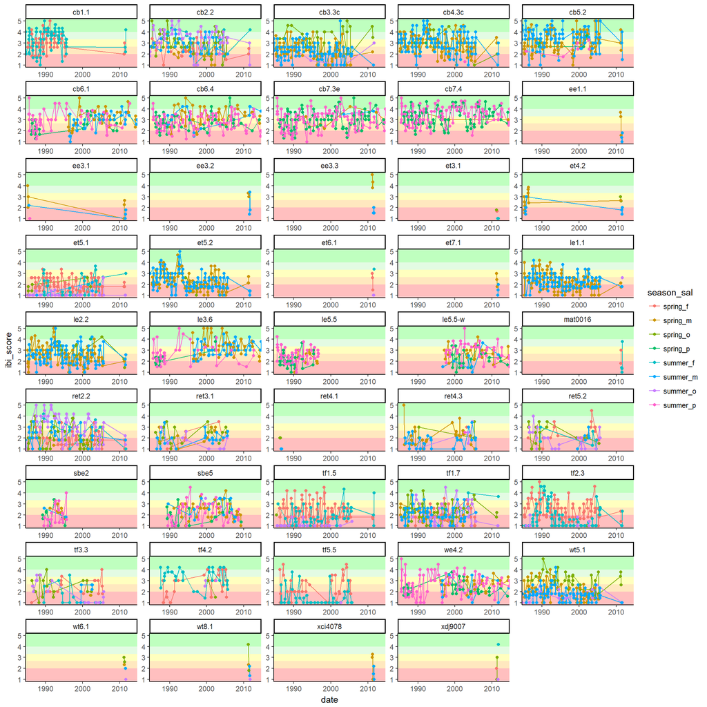

```r
min.date <- min(ibi.df$date, na.rm = TRUE)
max.date <- max(ibi.df$date, na.rm = TRUE)

ggplot(data = ibi.df, aes(date, ibi_score, group = season_sal, color = season_sal)) +
  theme_classic() +
  scale_x_date(limits = c(min(ibi.df$date, na.rm = TRUE), max(ibi.df$date, na.rm = TRUE)), expand = c(0, 0)) +
  scale_y_continuous(limits = c(0.8, 5.2), expand = c(0, 0)) +
  annotate("rect", xmin = min.date, xmax = max.date, ymin = 0.8, ymax = 2, fill = "red", alpha = 0.25) +
  annotate("rect", xmin = min.date, xmax = max.date, ymin = 2, ymax = 2.67, fill = "orange", alpha = 0.25) +
  annotate("rect", xmin = min.date, xmax = max.date, ymin = 2.67, ymax = 3.33, fill = "yellow", alpha = 0.25) +
  annotate("rect", xmin = min.date, xmax = max.date, ymin = 3.33, ymax = 4, fill = "lightgreen", alpha = 0.25) +
  annotate("rect", xmin = min.date, xmax = max.date, ymin = 4, ymax = 5.2, fill = "green", alpha = 0.25) +
  geom_line() +
  geom_point() +
  facet_wrap(~ station, ncol = 5, scales = "free")
```

These figures are the same as the previous figures but the plots have been divided by index (e.g. Spring Freshwater and Summer Polyhaline) to reduce clutter.

[figure not shown]

```r
ggplot(data = ibi.df, aes(date, ibi_score, group = season_sal, color = season_sal)) +
  theme_classic() +
  scale_x_date(limits = c(min(ibi.df$date, na.rm = TRUE), max(ibi.df$date, na.rm = TRUE)), expand = c(0, 0)) +
  scale_y_continuous(limits = c(0.8, 5.2), expand = c(0, 0)) +
  annotate("rect", xmin = min.date, xmax = max.date, ymin = 0.8, ymax = 2, fill = "red", alpha = 0.25) +
  annotate("rect", xmin = min.date, xmax = max.date, ymin = 2, ymax = 2.67, fill = "orange", alpha = 0.25) +
  annotate("rect", xmin = min.date, xmax = max.date, ymin = 2.67, ymax = 3.33, fill = "yellow", alpha = 0.25) +
  annotate("rect", xmin = min.date, xmax = max.date, ymin = 3.33, ymax = 4, fill = "lightgreen", alpha = 0.25) +
  annotate("rect", xmin = min.date, xmax = max.date, ymin = 4, ymax = 5.2, fill = "green", alpha = 0.25) +
  geom_line(na.rm = TRUE) +
  geom_point(na.rm = TRUE) +
  facet_wrap(~ station + season_sal, ncol = 5, scales = "free")
```

Another way of looking at the data above is represent all of the samples for a particular station in a box-and-whisker plot. This provides an a good summary of the scores for each station. However, this plot could be miss leading because the majority of stations have frequencies and provides no frame of reference for changes overtime.

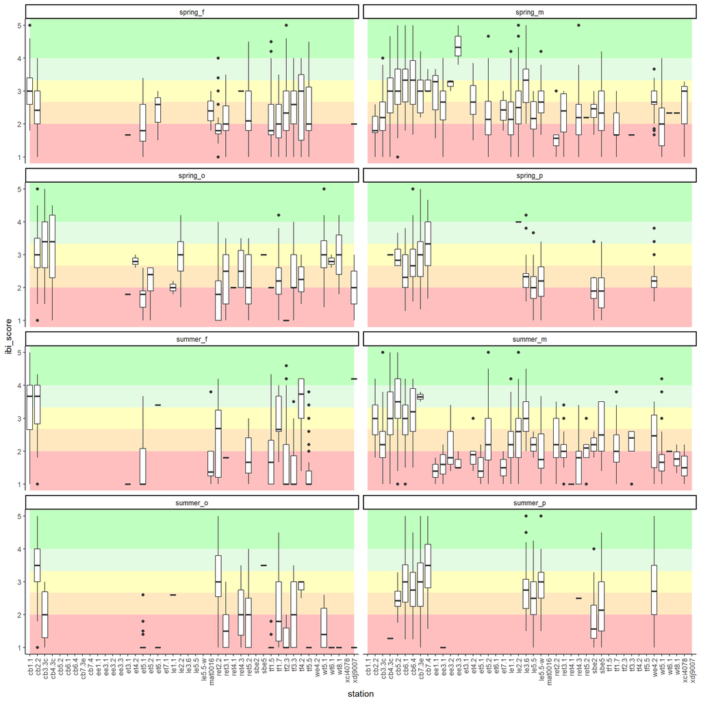

```r
station.vec <- sort(unique(ibi.df$station))
min.station <- station.vec[1]
max.station <- station.vec[length(station.vec)]
ggplot(data = ibi.df, aes(station, ibi_score)) +
  theme_classic() +
  #scale_x_discrete(expand = c(0, 0)) +
  scale_y_continuous(limits = c(0.8, 5.2), expand = c(0, 0)) +
  annotate("rect", xmin = min.station, xmax = max.station, ymin = 0.8, ymax = 2, fill = "red", alpha = 0.25) +
  annotate("rect", xmin = min.station, xmax = max.station, ymin = 2, ymax = 2.67, fill = "orange", alpha = 0.25) +
  annotate("rect", xmin = min.station, xmax = max.station, ymin = 2.67, ymax = 3.33, fill = "yellow", alpha = 0.25) +
  annotate("rect", xmin = min.station, xmax = max.station, ymin = 3.33, ymax = 4, fill = "lightgreen", alpha = 0.25) +
  annotate("rect", xmin = min.station, xmax = max.station, ymin = 4, ymax = 5.2, fill = "green", alpha = 0.25) +
  geom_boxplot() +
  theme(axis.text.x = element_text(angle = 90, hjust = 1, vjust = 0.5)) +
  facet_wrap(~season_sal, ncol = 2)
```

## Validation

### Import Old Values

Import metric values, scores, IBI values, and ratings calculated by Jacqueline M. Johnson of the Chesapeake Bay Program over 10 years ago. This data provides and independent set of metric values, scores, IBI values, and index ratings to compare to the values determined in this document.

```r
old.org.df <- read_excel("D:/ZSmith/Projects/PIBI/phyto/data/jackie_data/Data 2013_4plus-phyto-metrics.xlsx",
                         sheet = "DATA_4+biometrics",
                         skip = 1) %>%
  clean_up()
```

Metrics and scores are in a wide data format, where each metric or score represents a column. Create a vector of the metrics of interest. The score columns have the same names as the metrics but “__1" is added as a suffix. Therefore, `scores.vec` is created by pasting “__1" on to the end of each of the strings in `metrics.vec`.

```r
metrics.vec <- c("chl_surf", "biomass_chl_ratio", "cyano_biomass", "doc",
                 "pheo", "tot_biomass", "diatom_biomass", "dino_biomass",
                 "prorocentrum_min_abund", "microcystis_aer_abund",
                 "crypto_bio_pct")

scores.vec <- paste0(metrics.vec, "__1")
```

Remove all unnecessary columns.

```r
old.sub <- old.org.df %>%
  select(station, sample_date, season, ibi_layer, ibi_salzone, metrics.vec, scores.vec)
```

Remove the score columns from `old.org.df` and transform the metric data to a long data format.

```r
old.metrics <- old.sub %>%
  select(-one_of(scores.vec)) %>%
  gather(metric, old_metric_value, -station, -sample_date, -season, -ibi_layer, -ibi_salzone)
```

Remove the metric columns from `old.org.df` and transform the score data to a long data format. Remove the “__1" suffix from the scores name, which is just a reference to the metric name.

```r
old.score <- old.sub %>%
  select(-one_of(metrics.vec)) %>%
  gather(metric, old_score_value, -station, -sample_date, -season, -ibi_layer, -ibi_salzone) %>%
  mutate(metric = str_replace(metric, "__1", "")) %>%
  group_by(station, sample_date, season, ibi_layer, ibi_salzone) %>%
  mutate(old_ibi_score = mean(old_score_value, na.rm = TRUE)) %>%
  ungroup()
```

`old.metrics` and `old.score` are joined together by `station`, `sample_date`, `season`, `ibi_layer`, `ibi_salzone`, and `metric`. This provides both the metric value and score in a long data format. In other words each row represents a unique events (`unique_id`) metric value (`old_metric_value`) and score (`old_score_value`).

```r
old.df <- full_join(old.metrics, old.score,
                    by = c("station", "sample_date", "season",
                           "ibi_layer", "ibi_salzone", "metric"))
```

Convert column names and metric names to be consistent with the names found in `ratings.df`.

```r
old.df <- left_join(old.df, old.org.df,
                    by = c("station", "sample_date", "season", "ibi_layer", "ibi_salzone")) %>%
  select(station, sample_date, season, ibi_layer, ibi_salzone, metric,
         old_metric_value, old_score_value, old_ibi_score, pibi_rank) %>%
  rename(layer = ibi_layer,
         salzone = ibi_salzone,
         date = sample_date) %>%
  mutate(date = as.Date(date),
         metric = case_when(
           metric == "chl_surf" ~ "surface_chla",
           metric == "biomass_chl_ratio" ~ "total_phyto_biomass_chla_ratio",
           metric == "cyano_biomass" ~ "cyanophyte_biomass",
           metric == "pheo" ~ "pheophytin",
           metric == "tot_biomass" ~ "total_phyto_biomass",
           metric == "dino_biomass" ~ "dinoflagellate_biomass",
           metric == "prorocentrum_min_abund" ~ "prorocentrum_minimum_abundance",
           metric == "microcystis_aer_abund" ~ "microcystis_aeruginosa_abundance",
           metric == "crypto_bio_pct" ~ "pct_cryptophyte",
           TRUE ~ metric
         ))
```

### Modify Old Values

Re-score the metric values from `old.df` using `score_phyto()`. This allows the user to compare the new scoring procedure in this document to the independent scoring procedure created by Jacqueline M. Johnson of the Chesapeake Bay Program in SQL.

```r
old.rescored <- old.df %>%
  rename(value = old_metric_value) %>%
  unite(unique_id, station, layer, date, season, salzone, remove = FALSE) %>%
  score_phyto(pico.warning = FALSE)
```

Calculate the IBI score based on the scores calculated in the previous code chunk.

```r
old.rescored <- old.rescored %>%
  group_by(unique_id) %>%
  mutate(ibi_score = mean(score, na.rm = TRUE),
         old_ibi_score = mean(old_score_value, na.rm = TRUE)) %>%
  ungroup()
```

Rate the unique events (`unique_id`) IBI score calculated in the previous code chunk using `rate_phyto()`.

```r
old.rescored <- rate_phyto(old.rescored)
```

### Scoring Disagreement

Identify IBI scores re-calculated in this document that differ from the IBI scores calculated by Jacqueline M. Johnson. All numeric values are rounded to the hundredth place to remove minor discrepancies between the values being compared. The absolute difference between the re-calculated IBI score and Jacqueline M. Johnson’s IBI score is calculated (`ibi_diff`). Rows are sorted to present IBI score differences in descending order (`ibi_diff`) and only rows where the IBI differences disagree (`ibi_diff > 0`) are retained. This data frame can be used to explore differences in individual metric scores that are causing discrepancies between the two IBI values. Season (`season`) and salinity zone (`salzone`) are extracted from the unique event identifier (`unique_id`) and combined (`unite()`) to represent phytoplankton index names. Metrics (`metric`) and indices (`index`) are converted to factors to make them easier to plot in subsequent code chunks.

```r
disagree.df <- old.rescored %>%
  mutate_if(is.numeric, round, digits = 2) %>%
  mutate(ibi_diff = abs(old_ibi_score - ibi_score)) %>%
  arrange(desc(ibi_diff)) %>%
  select(unique_id, metric, value, old_score_value, score, old_ibi_score, ibi_score, ibi_diff, pibi_rank, rating) %>%
  separate(unique_id, c("station", "layer", "date", "season", "salzone"), sep = "_", remove = FALSE) %>%
  unite(index, c("season", "salzone")) %>%
  select(-station, -layer, -date) %>%
  mutate(metric = factor(metric),
         index = factor(index)) %>%
  filter(ibi_diff > 0)
```

Focus on just the IBI scores that differ. Categorize the IBI score differences (`ibi_diff`) into bins representing 0.5 increments.

```r
disagree.ibi <- disagree.df %>%
  select(unique_id, index, old_ibi_score, ibi_score, ibi_diff, pibi_rank, rating) %>%
  mutate(disagree_bin = case_when(
    ibi_diff > 0 & ibi_diff <= 0.5 ~ "0 < IBI Score <= 0.5",
    ibi_diff > 0.5 & ibi_diff <= 1 ~ "0.5 < IBI Score <= 1.0",
    ibi_diff > 1 & ibi_diff <= 1.5 ~ "1.0 < IBI Score <= 1.5",
    ibi_diff > 1.5 & ibi_diff <= 2 ~ "1.5 < IBI Score <= 2.0",
    ibi_diff > 2 & ibi_diff <= 2.5 ~ "2.0 < IBI Score <= 2.5",
    ibi_diff > 2.5 & ibi_diff <= 3 ~ "2.5 < IBI Score <= 3.0",
    ibi_diff > 3 & ibi_diff <= 3.5 ~ "3.0 < IBI Score <= 3.5",
    ibi_diff > 3.5 & ibi_diff <= 4 ~ "3.5 < IBI Score <= 4.0",
    TRUE ~ "ERROR"
  )) %>%
  distinct()
```

If at there is at least one IBI score disagreement, then plot the counts of IBI score disagreement for each index (`index`). The bins created in the previous code chunk can be used to divide up the data into separate plots and provide a little bit more information regarding how much the index scores differ.

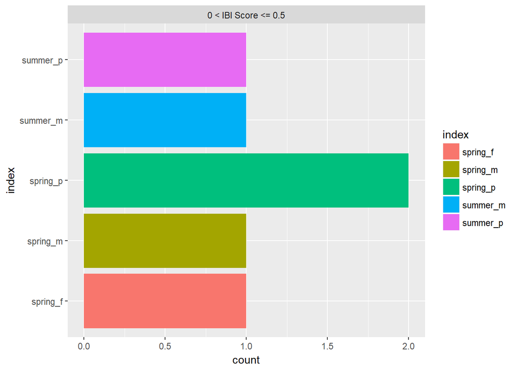

```r
if (nrow(disagree.ibi) > 0) {
  ggplot(disagree.ibi, aes(index, fill = index)) +
    geom_bar() +
    facet_wrap(~ disagree_bin, scales = "free_x") +
    coord_flip()
}
```

Focus just on scores that differ, which makes it easier to identify errors in this documents code. Subset `disagree.df` to only include metrics (`metric`), metric values (`value`), Jacqueline M. Johnson’s scores (`old_score_value`), and this documents re-scored values (`score`). Find the absolute difference (`score_diff`) between Jacqueline M. Johnson’s scores (`old_score_value`) and this documents re-scored values (`score`). Only rows where the scores disagree (`score_diff > 0`) are retained.

```r
disagree.score <- disagree.df %>%
  select(unique_id, index, metric, value, old_score_value, score) %>%
  distinct() %>%
  mutate(score_diff = abs(old_score_value - score)) %>%
  filter(score_diff > 0) %>%
  group_by(metric, index) %>%
  summarize(count = n()) %>%
  ungroup() %>%
  tidyr::complete(metric, index) %>%
  mutate(count = if_else(is.na(count), as.integer(0), count))
```

If there is at least one metric score disagreement, plot the counts of score disagreement for each metric by index (`index`).

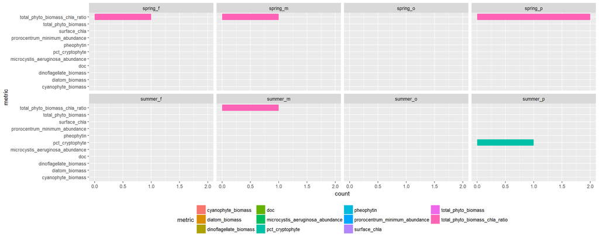

```r
if (nrow(disagree.score) > 0) {
  ggplot(disagree.score, aes(metric, count, fill = metric)) +
    geom_bar(stat = "identity") +
    coord_flip() +
    facet_wrap(~index, ncol = 4) +
    theme(legend.position = "bottom")
}
```

### Metric Disagreement

This section compares the values found in this document to the values found by Jacqueline M. Johnson. The previous section was good for identifying issues related to scoring the metrics. This section identifies issues related to the metric values. The discrepancies found here most likely do not have to deal with the formula used to calculate the metrics but probably stem from differences in how the taxonomic counts are prepared.

Values from this document (`ratings.df`) are merged with Jacqueline M. Johnson’s values (`old.df`). Season (`season`) and salinity zone (`salzone`) are combined (`unite()`) to represent phytoplankton index names. Metrics (`metric`), indices (`index`), and data sources (`source`) are converted to factors to make them easier to plot in subsequent code chunks.

```r
join.df <- left_join(ratings.df, old.df, by = c("station", "date", "season", "salzone",  "metric")) %>%
  filter(date <= max(old.df$date)) %>%
  unite(index, season, salzone) %>%
  left_join(unique(bay.df[, c("unique_id", "source")]), by = "unique_id") %>%
  mutate(index = factor(index),
         metric = factor(metric),
         source = factor(source))
```

The numeric values are all rounded to the hundredth place to reduce the detection of minor discrepancies. The absolute difference between the re-calculated IBI score and Jacqueline M. Johnson’s IBI score is calculated (`ibi_diff`). Rows are sorted to present IBI score differences in descending order (`ibi_diff`) and only rows where the IBI differences disagree (`ibi_diff > 0`) are retained. This data frame can be used to explore differences in individual metric scores that are causing discrepancies between the two IBI values.

```r
join.df <- join.df %>%
  mutate_if(is.numeric, round, digits = 2) %>%
  mutate(metric_diff = abs(value - old_metric_value),
         score_diff = abs(score - old_score_value),
         ibi_diff = abs(ibi_score - old_ibi_score)) %>%
  select(unique_id,  metric, index, source,
         value, old_metric_value, metric_diff,
         score, old_score_value, score_diff,
         ibi_score, old_ibi_score, ibi_diff,
         rating, pibi_rank)
```

Identify IBI scores calculated in this document that differ from the IBI scores calculated by Jacqueline M. Johnson.

```r
diff.df <- join.df %>%
  filter(ibi_diff > 0) %>%
  arrange(desc(ibi_diff), desc(score_diff), desc(metric_diff)) %>%
  distinct()
```

Focus on just the IBI scores that differ. Categorize the IBI score differences (`ibi_diff`) into bins representing 0.5 increments.

```r
diff.ibi <- diff.df %>%
  select(-metric, -value, -old_metric_value, -metric_diff,
         -score, -old_score_value, - score_diff) %>%
  mutate(disagree_bin = case_when(
    ibi_diff > 0 & ibi_diff <= 0.5 ~ "0 < IBI Score <= 0.5",
    ibi_diff > 0.5 & ibi_diff <= 1 ~ "0.5 < IBI Score <= 1.0",
    ibi_diff > 1 & ibi_diff <= 1.5 ~ "1.0 < IBI Score <= 1.5",
    ibi_diff > 1.5 & ibi_diff <= 2 ~ "1.5 < IBI Score <= 2.0",
    ibi_diff > 2 & ibi_diff <= 2.5 ~ "2.0 < IBI Score <= 2.5",
    ibi_diff > 2.5 & ibi_diff <= 3 ~ "2.5 < IBI Score <= 3.0",
    ibi_diff > 3 & ibi_diff <= 3.5 ~ "3.0 < IBI Score <= 3.5",
    ibi_diff > 3.5 & ibi_diff <= 4 ~ "3.5 < IBI Score <= 4.0",
    TRUE ~ "ERROR"
  )) %>%
  distinct() %>%
  arrange(desc(ibi_diff))
```

If at there is at least one IBI score disagreement, then plot the counts of IBI score disagreement for each index (`index`). The bins created in the previous code chunk can be used to divide up the data into separate plots and provide a little bit more information regarding how much the index scores differ.

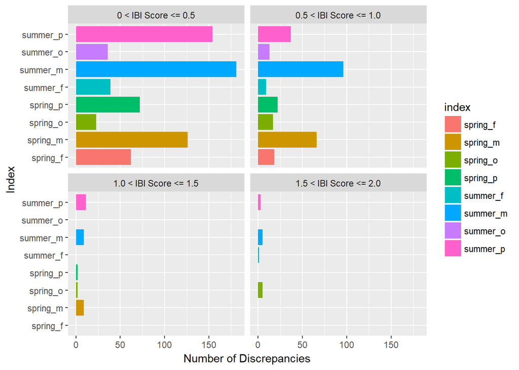

```r
if (nrow(diff.ibi) > 0) {
  ggplot(diff.ibi, aes(index, fill = index)) +
    geom_bar() +
    facet_wrap(~ disagree_bin) +
    xlab("Index") +
    ylab("Number of Discrepancies") +
    coord_flip()
}
```

```r
diff.score <- diff.df %>%
  select(unique_id, index, source,  metric, value, old_score_value, score) %>%
  distinct() %>%
  mutate(score_diff = abs(old_score_value - score)) %>%
  filter(score_diff > 0)
```

If there is at least one metric score disagreement, plot the counts of score disagreement for each metric by index (`index`).

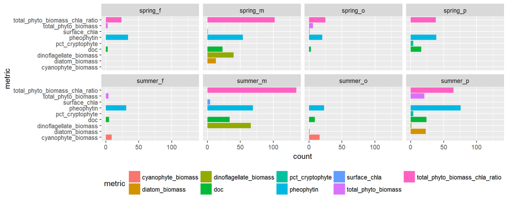

```r
if (nrow(diff.score) > 0) {
  ggplot(diff.score, aes(metric, fill = metric)) +
    geom_bar() +
    coord_flip() +
    facet_wrap(~index, ncol = 4)+
    theme(legend.position = "bottom")
}
```

More information can be gleaned from the previous plot if the data source (`source`) is also used as a grouping factor. Counts of score differences are summed by `metric`, `index`, and `source`.

```r
diff.score.source <- diff.score %>%
  group_by(metric, index, source) %>%
  summarize(count = n()) %>%
  ungroup() %>%
  tidyr::complete(metric, index, source) %>%
  mutate(count = if_else(is.na(count), as.integer(0), count))
```

If there is at least one metric score disagreement for `diff.score.source`, plot the counts of score disagreement for each metric by source (`source`) and index (`index`).

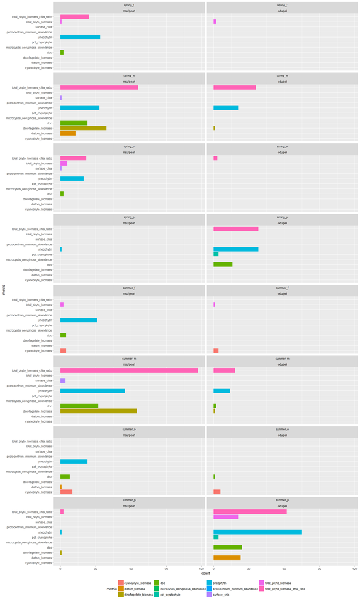

```r
if (nrow(diff.score.source) > 0) {
  ggplot(diff.score.source, aes(metric, count, fill = metric)) +
    geom_bar(stat = "identity") +
    coord_flip() +
    facet_wrap(~index + source, ncol = 2) +
    theme(legend.position = "bottom")
}
```

## Conclusion

Currently, there are a large number of descrepancies between the IBI values calculated in this document and the IBI values found by Jacqueline M. Johnson of the Chesapeake Bay Program. The scoring functions provided in this document appear to be functioning correctly based on the Scoring Disagreement section. After using the scoring functions to re-score the metric values provided by Jacqueline M. Johnson, several errors were identified and corrected. These corrections reducing the scoring descrepancies to less than 10. Most of the remaining descrepancies are found at scoring thresholds. Jacqueline M. Johnson’s code provided the best description of scoring thresholds, which have been replicated in the Scoring Functions section; at this time, I have no justification for altering the thresholds further, so the few descrapencies will remain. Ultimately, the Scoring Disagreement section suggests that any remaining descrapancies between the values found in this document and the values values found by Jacqueline M. Johnson are caused by differences in metric calculations and/or, more likely, differences in taxonomic count preperations. So far, no table has been found representing Jacqueline M. Johnson’s prepared taxonomic counts. This table would make it easier to identify descrepancies in how the taxa are prepared (e.g. excluded taxa or assigned carbon values). Without this table I need help identifying why these descrepancies exist. If you have any suggestions, please let me know.